# Atlanta Georgia

# Atlanta Georgia Data

This will be the h3 hash generation work for Atlanta, Georgia. The other city notebooks follow the same steps but with different sets of CBSA data.

Estimated time to run: <7 hours (ran overnight)

Load packages:

```r
library(ggplot2)
library(glue) # Interpreted String Literals
library(h3)
library(here) # A Simpler Way to Find Your Files
library(osmdata) # package for working with streets
library(sf) # Simple Features for R
library(tidycensus) # Load US Census Boundary and Attribute Data as 'tidyverse' and 'sf'-Ready Data Frames
library(tidyverse) # Easily Install and Load the 'Tidyverse'
library(tigris) # Load Census TIGER/Line Shapefiles
```

## Network data

Download OSM data for Atlanta [here](https://download.geofabrik.de/north-america/us/georgia.html). It will be a proto-buffer file (pbf). Save under `data-raw/r5_graph`.

## Census tracts

Obtain the census tracts for Atlanta. Note that [{tidycensus}](https://walker-data.com/tidycensus/) function `get_decenial()` allows the selection of state and county, but not metro area or city. Check the example [here](https://walker-data.com/census-r/spatial-analysis-with-us-census-data.html#identifying-geometries-within-a-metropolitan-area) to see how to select tracts in a city.

```r
options(tigris_use_cache = TRUE)

ga_tracts <- get_decennial(geography = "tract",
                           variables = "H1_001N",
                           state = "Georgia",
                           year = 2020,
                           geometry = TRUE
)
```

[output not shown]

```
Note: 2020 decennial Census data use differential privacy, a technique that
introduces errors into data to preserve respondent confidentiality.
ℹ Small counts should be interpreted with caution.
ℹ See https://www.census.gov/library/fact-sheets/2021/protecting-the-confidentiality-of-the-2020-census-redistricting-data.html for additional guidance.
```

```r
ga_city <- urban_areas(year = 2020) |>
  filter(str_detect(NAME10, "GA"))
```

A [core-based statistical area](https://en.wikipedia.org/wiki/Core-based_statistical_area) is a generous definition of the area of interest, since it contains an urban nucleus and also all neighboring communities that are tightly integrated with it. It is important to note that some of the neighboring communities share boundaries with the urban nucleus, but some are disconnected.

```r
atlanta_cbsa <- core_based_statistical_areas(year = 2020) |>
  filter(str_detect(NAME, "Atlanta"))
```

A much stricter definition of the area of interest would result from using the city boundaries, which can be obtained using `urban_areas()`:

```r
atlanta_city <- urban_areas(year = 2020) |>
  filter(str_detect(NAME10, "Atlanta"))
```

Plot the location of Atlanta CBSA within Georgia and its tracts:

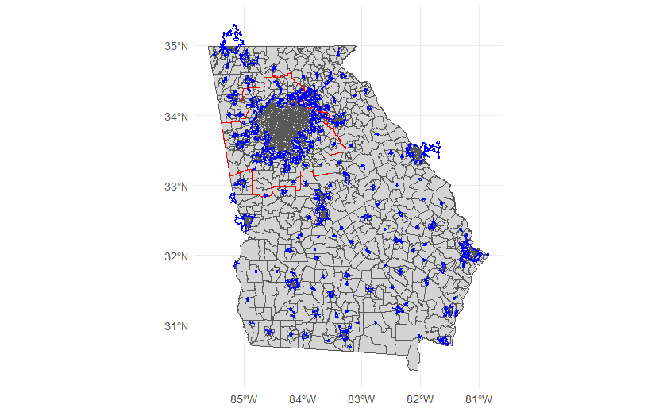

```r
ggplot() +
  geom_sf(data = ga_tracts,
          fill = "lightgrey") +
  geom_sf(data = atlanta_cbsa,
          color = "red",
          fill = NA) +
  geom_sf(data = ga_city,
          color = "blue",
          fill = NA) +
  theme_minimal()
```

Select all urban areas in Atlanta CBSA:

```r
atlanta_urban <- st_filter(ga_city, atlanta_cbsa)
```

Plot urban boundaries within the Atlanta CBSA:

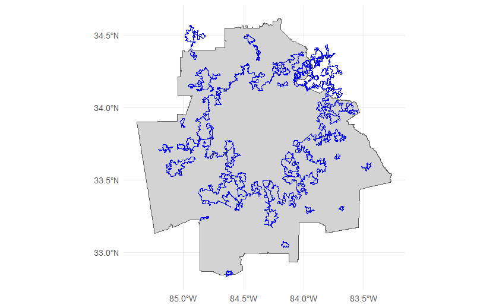

```r
ggplot() +
  geom_sf(data = atlanta_cbsa,
          fill = "lightgray") +
  geom_sf(data = atlanta_urban,
          color = "blue",
          fill = NA) +
  theme_minimal()
```

Obtain the Atlanta tracts:

```r
atlanta_tracts <- ga_tracts |>
  st_intersection(atlanta_urban)
```

Plot Atlanta’s urban tracts within the CBSA:

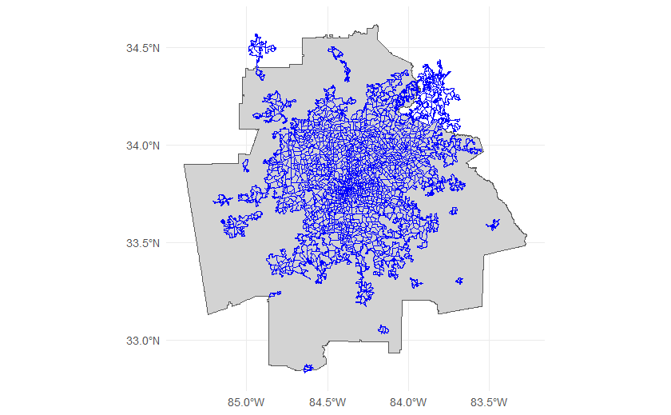

```r
ggplot() +
  geom_sf(data = atlanta_cbsa,
          fill = "lightgray") +
  geom_sf(data = atlanta_tracts,
          color = "blue",
          fill = NA) +
  theme_minimal()
```

## Geohashes

Use the coordinates of the centroid of Atlanta CBSA to obtain h3 polygons:

```r
coords <- st_centroid(atlanta_cbsa) |>
  st_coordinates()
print(coords)
```

```
             X       Y
[1,] -84.39957 33.6918
```

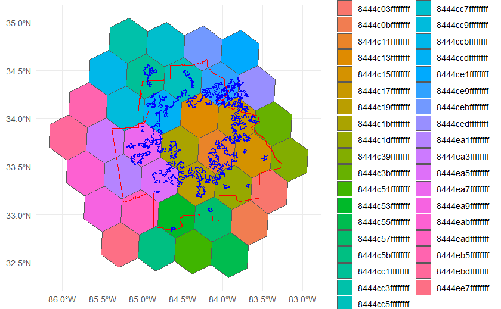

```r
atlanta_h3 <- geo_to_h3(c(rev(coords)),
                             res = 4) |>
  k_ring(3)

# k_ring sets the number of h3 rings to generate around the initial h3 point, typically 2 or 3 are required depending on the CBSA.

ggplot() +
  geom_sf(data = (h3_to_geo_boundary_sf(atlanta_h3)),
          aes(fill = h3_index)) +
    geom_sf(data = atlanta_cbsa,
          color = "red",
          fill = NA) +
  geom_sf(data = atlanta_urban,
          color = "blue",
          fill = NA) +
  theme_minimal()
```

```r
print.listof(h3_to_geo_boundary_sf(atlanta_h3))
```

```
h3_index :
 [1] "8444c1bffffffff" "8444c19ffffffff" "8444c11ffffffff" "8444c13ffffffff" "8444ccdffffffff"
 [6] "8444ea7ffffffff" "8444ea5ffffffff" "8444c53ffffffff" "8444c57ffffffff" "8444c1dffffffff"
[11] "8444c15ffffffff" "8444c17ffffffff" "8444ce9ffffffff" "8444cc5ffffffff" "8444cc1ffffffff"
[16] "8444cc9ffffffff" "8444ea3ffffffff" "8444ea1ffffffff" "8444eadffffffff" "8444c5bffffffff"
[21] "8444c51ffffffff" "8444c55ffffffff" "8444c0bffffffff" "8444c03ffffffff" "8444c39ffffffff"
[26] "8444c3bffffffff" "8444cedffffffff" "8444ce1ffffffff" "8444cebffffffff" "8444cc7ffffffff"
[31] "8444cc3ffffffff" "8444ccbffffffff" "8444eb5ffffffff" "8444ebdffffffff" "8444eabffffffff"
[36] "8444ea9ffffffff" "8444ee7ffffffff"

geometry :
Geometry set for 37 features
Geometry type: POLYGON
Dimension:     XY
Bounding box:  xmin: -86.17117 ymin: 32.34337 xmax: -82.93333 ymax: 35.04748
Geodetic CRS:  WGS 84
First 5 geometries:
```

```
POLYGON ((-84.54957 33.46067, -84.31343 33.5592...
POLYGON ((-84.33955 33.08822, -84.10461 33.1869...
POLYGON ((-84.09109 33.42208, -83.85587 33.5195...
POLYGON ((-84.30028 33.79429, -84.06386 33.8916...
POLYGON ((-84.76158 33.83307, -84.52423 33.9314...
```

Keep only the h3 indices that overlap with urban Atlanta (but discard any that overlap 0-10%):

```r
atlanta_h3 = c("8444c1bffffffff", "8444c19ffffffff", "8444c11ffffffff", "8444c13ffffffff", "8444ccdffffffff", "8444ea7ffffffff", "8444ea5ffffffff", "8444c53ffffffff", "8444c57ffffffff", "8444c1dffffffff", "8444c15ffffffff", "8444c17ffffffff", "8444ce9ffffffff", "8444cc5ffffffff", "8444cc1ffffffff", "8444ea1ffffffff", "8444cedffffffff")
```

Plot kept indices:

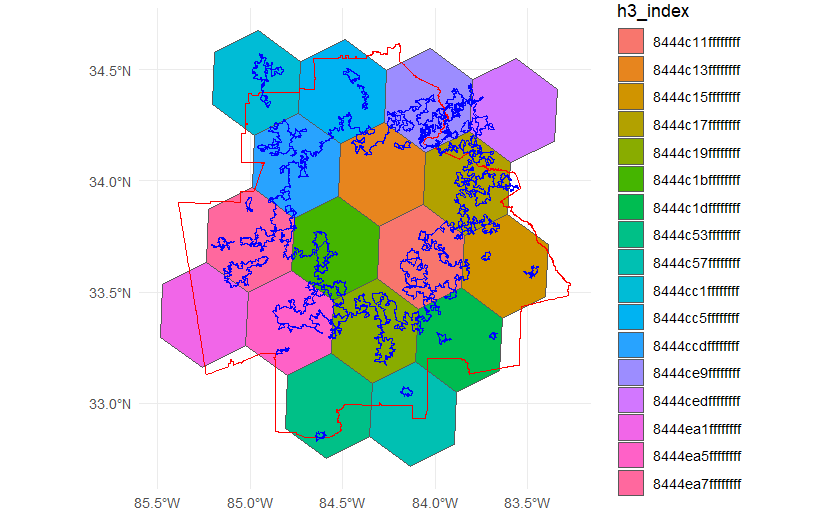

```r
ggplot() +
  geom_sf(data = h3_to_geo_boundary_sf(atlanta_h3),
          aes(fill = h3_index)) +
  geom_sf(data = atlanta_cbsa,
          color = "red",
          fill = NA) +
  geom_sf(data = atlanta_urban,
          color = "blue",
          fill = NA) +
  theme_minimal()
```

Obtain children hashes at a higher resolution (8):

```r
atlanta_h3 <- atlanta_h3 |>
  purrr::map(\(x) h3_to_children(x, res = 8)) |>
  unlist()
```

Choose only hexagons that touch urban Atlanta:

```r
atlanta_h3 <- h3_to_geo_boundary_sf(atlanta_h3) |>
  st_transform(crs = st_crs(atlanta_urban)) |>
  st_intersection(atlanta_urban)
atlanta_h3 <- atlanta_h3 |>
  pull(h3_index)
```

Plot resolution 8 hashes within Atlanta:

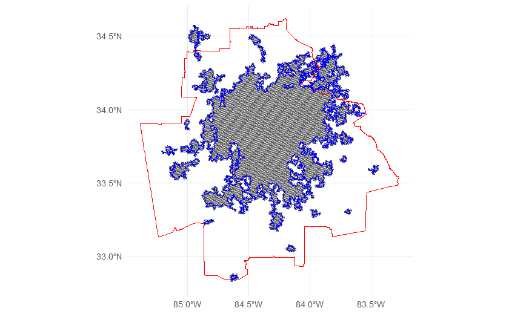

```r
ggplot() +
  geom_sf(data = h3_to_geo_boundary_sf(atlanta_h3)) +
  geom_sf(data = atlanta_cbsa,
          color = "red",
          fill = NA) +
  geom_sf(data = atlanta_urban,
          color = "blue",
          fill = NA) +
  theme_minimal()
```

Currently this is resolution 8:

```r
h3_get_resolution(atlanta_h3)
```

[output not shown]

```r
atlanta_h3 <- atlanta_h3 |>
  purrr::map(\(x) h3_to_children(x, res = 13)) |>
  unlist()
```

Check the size of an h3 hexagon:

```r
sample_h3 <- h3_to_geo_boundary_sf(atlanta_h3[1])

sample_h3 |>
  mutate(area = st_area(geometry))
```

```
Simple feature collection with 1 feature and 2 fields
Geometry type: POLYGON
Dimension:     XY
Bounding box:  xmin: -83.93499 ymin: 33.29046 xmax: -83.93491 ymax: 33.29054
Geodetic CRS:  WGS 84
         h3_index                       geometry           area
1 8d44c1c2800003f POLYGON ((-83.93494 33.2904... 41.33588 [m^2]
```

Information about housing characteristics. Explore the tables [here](https://data.census.gov/advanced?q=Housing) to get a sense of the variables that might be interesting to date the housing stock. For example, a search within the topic of “housing” shows that there is a set of variables with “physical characteristics”. The keywords for age of housing stock are “year” and “structure”. Next, use {tidycensus} to explore the variables available:

```r
v17 <- load_variables(2022,
                      "acs5",
                      cache = TRUE)


v17 |>
  filter(str_detect(concept, "Year") & str_detect(concept, "Structure"))
```

| name | label | concept | geography |
| --- | --- | --- | --- |
| B25034_001 | Estimate!!Total: | Year Structure Built | block group |
| B25034_002 | Estimate!!Total:!!Built 2020 or later | Year Structure Built | block group |
| B25034_003 | Estimate!!Total:!!Built 2010 to 2019 | Year Structure Built | block group |
| B25034_004 | Estimate!!Total:!!Built 2000 to 2009 | Year Structure Built | block group |
| B25034_005 | Estimate!!Total:!!Built 1990 to 1999 | Year Structure Built | block group |
| B25034_006 | Estimate!!Total:!!Built 1980 to 1989 | Year Structure Built | block group |
| B25034_007 | Estimate!!Total:!!Built 1970 to 1979 | Year Structure Built | block group |
| B25034_008 | Estimate!!Total:!!Built 1960 to 1969 | Year Structure Built | block group |
| B25034_009 | Estimate!!Total:!!Built 1950 to 1959 | Year Structure Built | block group |
| B25034_010 | Estimate!!Total:!!Built 1940 to 1949 | Year Structure Built | block group |

[output cut: 323 more lines]

Refine the search:

```r
v17 |>
  filter(str_detect(label, "Estimate!!Total:!!Built"))
```

| name | label | concept | geography |
| --- | --- | --- | --- |
| B25034_002 | Estimate!!Total:!!Built 2020 or later | Year Structure Built | block group |
| B25034_003 | Estimate!!Total:!!Built 2010 to 2019 | Year Structure Built | block group |
| B25034_004 | Estimate!!Total:!!Built 2000 to 2009 | Year Structure Built | block group |
| B25034_005 | Estimate!!Total:!!Built 1990 to 1999 | Year Structure Built | block group |
| B25034_006 | Estimate!!Total:!!Built 1980 to 1989 | Year Structure Built | block group |
| B25034_007 | Estimate!!Total:!!Built 1970 to 1979 | Year Structure Built | block group |
| B25034_008 | Estimate!!Total:!!Built 1960 to 1969 | Year Structure Built | block group |
| B25034_009 | Estimate!!Total:!!Built 1950 to 1959 | Year Structure Built | block group |
| B25034_010 | Estimate!!Total:!!Built 1940 to 1949 | Year Structure Built | block group |
| B25034_011 | Estimate!!Total:!!Built 1939 or earlier | Year Structure Built | block group |

```r
housing_block_group_ga <- get_acs(geography = "cbg",
                               state = "GA",
                               variables = v17 |>
                                 filter(str_detect(label, "Estimate!!Total:!!Built")) |>
                                 pull(name),
                               year = 2022,
                               geometry = TRUE)
#trying to add "state = c("AZ", "TX", "TN", "GA", "LA")" did not work, so I am making all the housing block groups separate.
```

Filter by urban Atlanta:

```r
housing_block_group_ga <- housing_block_group_ga |>
  st_intersection(atlanta_urban)
```

The proportion of buildings built during certain periods could be a good indicator of post-war suburban development.

Save data objects:

```r
# Tracts
save(atlanta_tracts,
     file = glue::glue(here::here(),
                       "/data-raw/atlanta_tracts.rda"),
     compress = "bzip2")
# Urban boundaries
save(atlanta_urban,
     file = glue::glue(here::here(),
                       "/data-raw/atlanta_urban.rda"),
     compress = "bzip2")
# CBSA boundary
save(atlanta_cbsa,
     file = glue::glue(here::here(),
                       "/data-raw/atlanta_cbsa.rda"),
     compress = "bzip2")

# h3 identifiers from which the coordinates can be retrieved for routing
save(atlanta_h3,
     file = glue::glue(here::here(),
                       "/data-raw/atlanta_h3.rda"),
     compress = "bzip2")

# h3 identifiers from which the coordinates can be retrieved for routing
save(housing_block_group_ga,
     file = glue::glue(here::here(),
                       "/data-raw/housing_block_group_ga.rda"),
     compress = "bzip2")
```